# *Vitis* Roots Utilize a Conserved 3’UTR Response Pattern Under Water Deficit Conditions

9/23/2021

### **Introduction**

The establishment of more drought tolerant food crops is an ever-increasing necessity with the threat of global climate change impacting food security. A crucial step in developing such crops is studying gene expression under water deficit conditions to identify genes related to drought response and the regulation of said genes within the stressed plant.

The grapevine (*Vitis vinifera*) is a culturally and economically significant crop cultivated worldwide for direct consumption and wine production. Commercial cultivation of grapes typically involves grafting the scion of a cultivar intended to bear fruit onto a reciprocally cut rootstock which remains in the ground for several decades. With the frequency of droughts and microclimate changes anticipated to increase in the near future, viticulturists have a significant interest in the development of more drought tolerant rootstocks to reduce the risk of severe fruit loss.

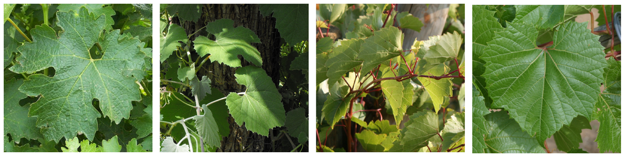

Four grapevine species (*Vitis vinifera* cv. Cabernet Sauvignon clone-8, *Vitis riparia*, *Vitis champinii*, and *Vitis vinifera* x *Vitis girdiana*) were studied by the lab to investigate differences in *Vitis* water deficit response. *Vitis vinifera* cv. Cabernet Sauvignon is a popular wine grape with significant economic importance and moderate drought tolerance. *Vitis champinii* cv. Ramsey is a grape native to the southwestern United States and is considered moderately drought tolerant. *Vitis vinifera* x *Vitis girdiana* SC2 is a hybrid desert grape found in southern Nevada and California that is also thought to be moderately drought tolerant. Finally, *Vitis riparia* cv. Riparia Gloire is a grape indigenous to riparian environments in the northeastern United States and is considered highly drought sensitive.

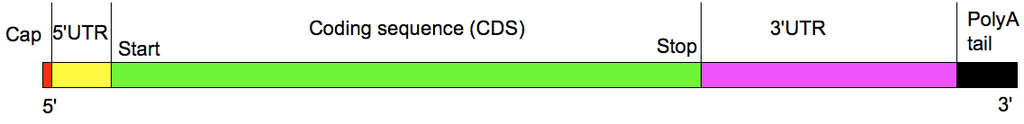

The 3’ untranslated region (3’UTR) is one of many regulator elements utilized by eukaryotes to post-transcriptionally regulate messenger RNA (mRNA) transcripts. The 3’UTR, located after the stop codon and prior to the poly-A tail, is formed when the poly-A tail is elongated at one of several poly-A sites, impacting the length and content of the final 3’UTR of mature mRNA. The switching of poly-A sites, called alternative polyadenylation (APA), leads to the expression of different 3’UTRs which in turn impact transcript stability, cellular localization, and translation frequency. APA is utilized to respond to environmental stress. *Arabidopsis thaliana* induces the expression of transcripts with shorter 3’UTRs during salt stress as a method of reducing transcript regulation. A decrease in transcript regulatory elements may be desirable when responding to a stressful environment where energy conservation and enduring stress response signals are necessary.

The role of APA during abiotic stress response is poorly understood in woody plants like *Vitis*. To begin to address this gap in knowledge, APAtrap was used on RNA-Seq series PRJNA516950 to identify the differential expression of 3’UTRs between *Vitis* leaves and roots and between control and water deficit treatment groups to determine the potential role of APA in *Vitis* organ differentiation and water deficit response. APAtrap comparisons revealed 3’UTR expression in *Vitis* to be organ-specific, treatment-specific, and species-specific. Additionally, a shared 3’UTR expression pattern during water deficit treatment in the roots of three of the four tested *Vitis* species potentially suggests an unstudied conserved mechanism of water deficit stress response which may be targeted for the development of more drought-tolerant *Vitis* rootstocks.

### **Results**

#### *Certain stress response transcripts in Vitis express lengthened 3’UTR isoforms in the roots relative to leaves during initial water deficit exposure*

Differential expression of the 3’UTR between *Vitis* root and leaf transcripts within species and treatment was investigated to determine the impact of organ type on 3’UTR expression. Considering all variables and conditions, roots differentially expressed transcripts with shortened 3’UTRs more abundantly than leaves (**Table 1**) though this generalization was not consistent between all species, treatments, and time points.

**Table 1: Transcripts Expressed in *Vitis* Roots Tend to Differentially Express Shorter 3’UTRs than *Vitis* Leaves Independent of Treatment.** *The number of unique transcripts detected in any of the four tested species which were either significantly lengthened or shortened in root samples relative to leaf samples is shown under control and water deficit treatments.*

| Treatment | Lengthened (Relative to leaves) | Shortened (Relative to leaves) |
| --- | --- | --- |
| Control | 306 | 1834 |
| Water deficit | 907 | 1375 |

Differential expression of the 3’UTR by organ is species-specific in *Vitis* (**Figure 1**). The majority of differentially expressed 3’UTRs in Cabernet Sauvignon were shorter in roots relative to leaves independent of treatment. Riparia Gloire, on the other hand, exhibited treatment-dependent 3’UTR isoform usage between organs. Differentially expressed 3’UTRs in control Riparia were mainly shortened in roots relative to leaves. Under water deficit, differential expression flipped such that the majority of 3’UTRs in Riparia Gloire roots were lengthened relative to leaves. Ramsey and SC2 3’UTR isoform usage varied by time and treatment. Under control conditions both expressed mainly shortened 3’UTRs in roots during week 1 and mainly lengthened 3’UTRs in roots during week 2. Water deficit treated Ramesy and SC2 flipped this expression with root transcripts during week 1 mainly expressing lengthened 3’UTRs relative to leaves and during week 2 mainly expressing shortened 3’UTRs relative to leaf transcripts.

**Figure 1: Percent of Differentially Expressed Shortened 3’UTRs In *Vitis* Roots Relative to Leaves During Control and Water Deficit Treatment.**

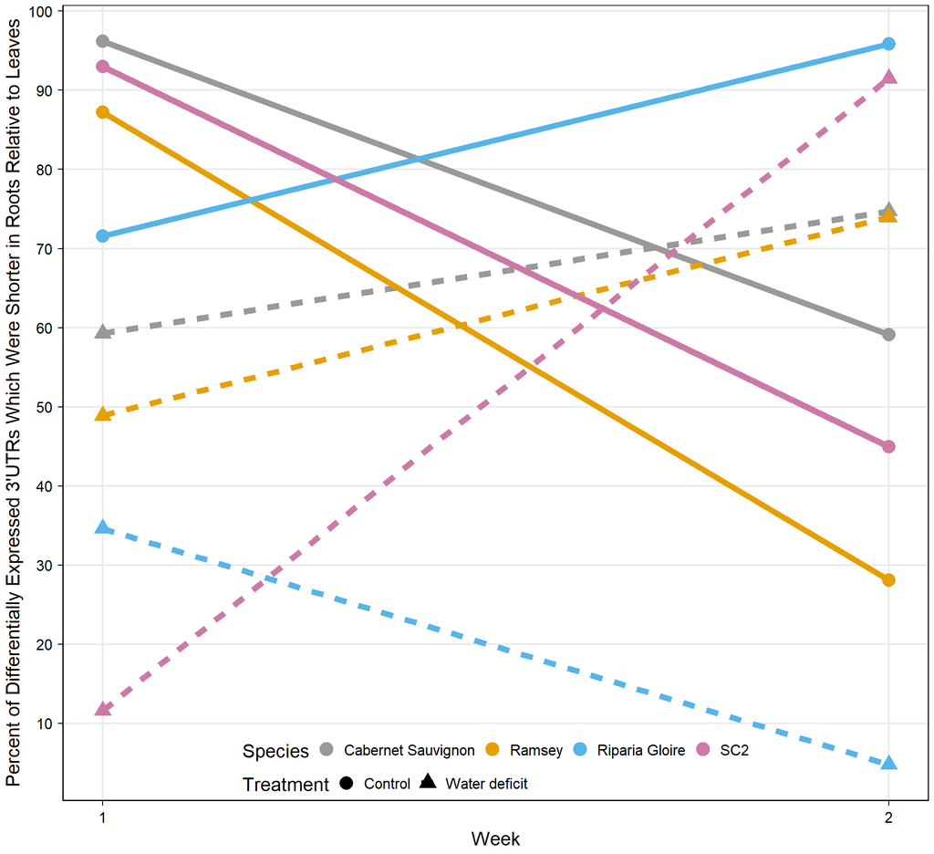

Although 3’UTR expression in roots and leaves was found to be substantially different between species, a core set of 35 genes which significantly differentially expressed 3’UTRs between roots and leaves identically across all four species within treatment was identified. Among them, four genes linked to water deficit response and abscisic acid signaling (GLUTATHIONE S-TRANSFERASE F4 (GSTF4), CALMODULIN 7 (CAM7), GLYCINE RICH PROTEIN 7 (GRP7), and REGULATOR OF CULLINS 1 (ROC1)) were expressed with lengthened 3’UTRs in roots relative to leaves across all tested species during week 1 of water deficit treatment, indicating 3’UTR isoform usage may be important in organ-specific water deficit response for these genes across *Vitis*.

#### *Organ-specific transcripts P4 and S2 reciprocally express 3’UTR isoforms by organ in Cabernet Sauvignon*

**Figure 2: Control Treated Cabernet Sauvignon Differentially Expresses Organ-Specific Transcripts by 3’UTR Between Roots and Leaves.**

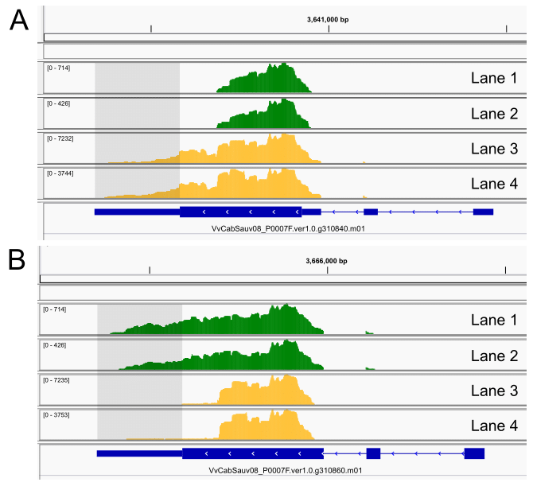

The uncharacterized, organ-specific, highly homologous genes P4 and S2 were both found to significantly differentially express transcript 3’UTRs by organ in control treated Cabernet Sauvignon. Visual inspection of the RNA-Seq data indicated that while the two transcripts were very similar, differential expression of the 3’UTR was reciprocally flipped between genes. The 3’UTR of P4 was longer in roots relative to leaves while in S2 the 3’UTR was longer in leaves relative to roots. This differential expression pattern was consistent between W1 and W2 of Control treatment. A screenshot of RNA-seq read coverage visualized in the Integrative Genomics Viewer is shown in **Figure 2** for P4 (A) and S2 (B) in a sample from week 1 control treated Cabernet Sauvignon leaves (Lane 1), week 2 control treated Cabernet Sauvignon leaves (Lane 2), week 1 control treated Cabernet Sauvignon roots (Lane 3), and week 2 control treated Cabernet Sauvignon roots (Lane 4). Green and gold tracks correspond to leaf and root samples respectively, and the 3’UTR of each transcript is highlighted in gray.

#### *Water deficit generally induces the expression of a shared 3’UTR expression pattern in Vitis roots*

Differential expression of the 3’UTR between control and water deficit treated samples within species and organ was investigated to observe the changes in *Vitis* 3’UTR expression during stress response. Water deficit treated *Vitis* leaves generally expressed transcripts with shortened 3’UTR isoforms more abundantly than control treated leaves while *Vitis* roots evenly expressed transcripts with lengthened and shortened 3’UTR isoforms between treatments (**Table 2**).

**Table 2: Differential Expression of Transcript 3’UTRs Under Water Deficit treatment is Organ-Specific in *Vitis*.** *The number of unique transcripts detected in any of the four tested species which were either significantly lengthened or shortened in water deficit treated samples relative to control treated samples is shown for leaves and roots.*

| Organ | Lengthened (Relative to control) | Shortened (Relative to control) |
| --- | --- | --- |
| Leaf | 629 | 1907 |
| Root | 1356 | 1373 |

3’UTR isoform expression in *Vitis* leaves during water deficit appeared to be species-specific (**Figure 3A and 3C**). Between weeks 1 and 2 of water deficit treatment, Ramsey leaves increased the expression of shortened 3’UTR isoforms while Cabernet Sauvignon and SC2 leaves decreased the expression of shortened 3’UTRs. Riparia expressed a high proportion of shortened 3’UTRs in leaves during both weeks of water deficit.

A shared pattern of 3’UTR isoform expression was observed in *Vitis* roots under water deficit (**Figure 3B and 3C**). Water deficit Cabernet Sauvignon, Ramsey, and SC2 roots all switched from expressing a high proportion of long 3’UTRs during week 1 of treatment to expressing a high proportion of short 3’UTRs during week 2 of treatment relative to control treated samples. Water deficit Riparia roots opposed this behavior by switching from a high proportion of short 3’UTRs in week 1 to a low proportion in week 2.

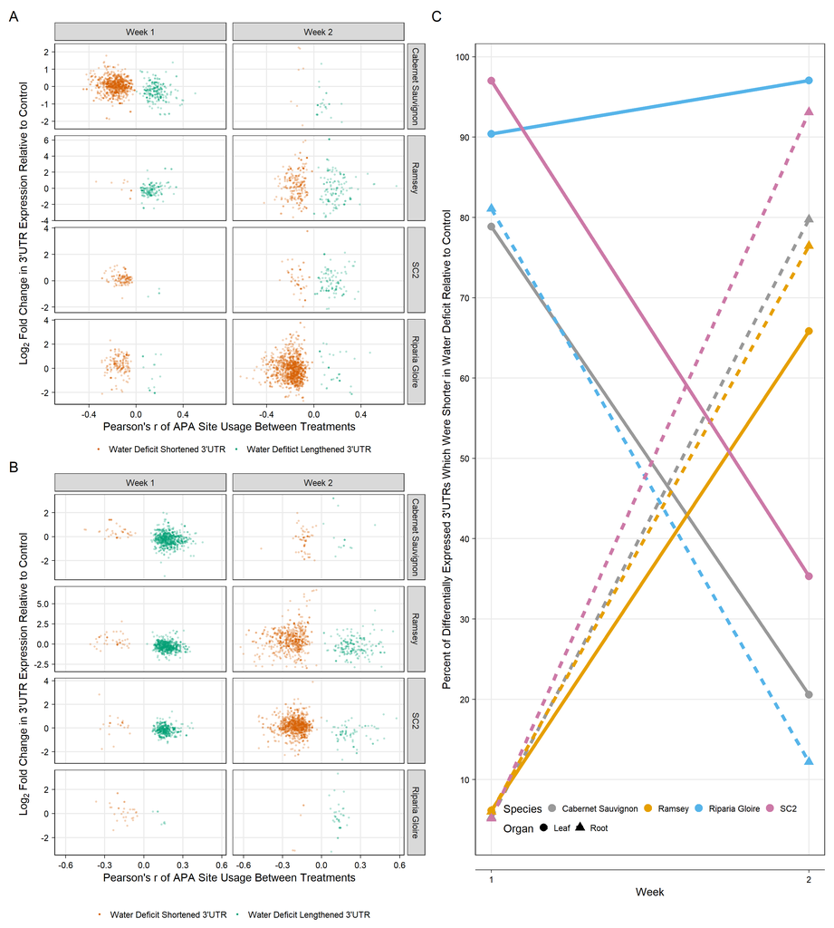

This shared 3’UTR expression pattern identified in Cabernet Sauvigon, Ramsey, and SC2 roots was further investigated to determine if any transcripts were sharing isoform expression amongst these three species. 223 transcripts shared lengthened 3’UTR isoform expression during water deficit (219 of which were expressed during week 1) and 38 transcripts shared shortened 3’UTR isoform expression during water deficit (33 of which were expressed during week 2). Gene ontology conducted on these subsets revealed that the shared transcripts with lengthened 3’UTR isoforms significantly shared stress response (GO0006950), translation (GO0006412), and cell growth (GO0016049) functions (**Figure 4**). Both shortened and lengthened differentially expressed transcripts were enriched in terms related to abiotic and external stimulus response (GO0009628, GO0009605) (**Figure 4**).

16 genes were found to be expressed with a long 3’UTR isoform during week 1 of water deficit and a short 3’UTR isoform during week 2 of water deficit across Cabernet Sauvignon, Ramsey, and SC2 roots, including PEPTIDYL-PROLYL CIS-TRANS ISOMERASE (PCKR1), UNIVERSAL STRESS PHOS32 (PHOS32), ATP-CITRATE SYNTHASE ALPHA CHAIN 2 (ACLA-2), and PEROXIDASE 73 (PER73), all of which are involved in stress response pathways. Such results indicate the shared 3’UTR isoform shifting noted in these species during water deficit may be related to the regulation of certain stress response transcripts in the roots.

**Figure 4: Gene Ontology Enrichment of Transcripts With Shared 3’UTRs Across Water Deficit Treated Cabernet Sauvignon, Ramsey, and SC2 Roots.**

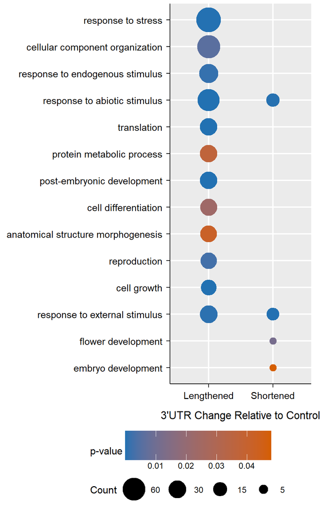

### **Discussion**

Comparisons between *Vitis* organs revealed that roots differentially express transcripts with shortened 3’UTR isoforms more frequently than leaves independent of treatment. However, 3’UTR expression by organ was found to be species-specific and thus no generalizing conclusions about *Vitis* organ 3’UTR isoform usage could be made. 3’UTR differential expression by organ shifted significantly under control conditions between weeks for all tested species. A portion of this may be attributed to regular oscillations in transcript expression over time. The methodology for sample collection may have also played a role in shifting 3’UTR expression. The RNA-Seq data used in this study was obtained from whole canopy and whole root system samples. Thus, plant growth and aging could not be controlled for in this analysis. Previous research has shown that cell aging and senescence is associated with transcriptome-wide lengthening of 3’UTRs as a method of increasing transcript degradation. Consequentially, the shifting 3’UTR isoform usage between weeks under control conditions could be due to differing ratios of sampled young and old tissue. This variability made comparing differential expression of 3’UTRs between organs difficult and left results mainly inconclusive.

*Vitis* roots tend to express certain stress response-related transcripts with a lengthened 3’UTR isoform when initially exposed to water deficit conditions. This behavior was observed in comparisons between organs and treatment groups. Four drought-responsive genes (GSTF4, CAM7, GRP7, and ROC1) expressed a lengthened 3’UTR isoform in roots relative to leaves during week 1 of water deficit treatment across all four tested species. These genes may play an organ-specific role during water deficit which necessitates differential expression of the 3’UTR.

Comparisons between treatment groups revealed that Cabernet Sauvignon, Ramsey, and SC2 roots share a 3’UTR expression pattern which may be involved in *Vitis* transcriptional regulation of stress response mechanisms. During week 1 of water deficit treatment these three species predominantly lengthened root transcript 3’UTRs relative to control treated samples while during week 2 of water deficit treatment, isoform usage shifted to predominantly expressing shortened 3’UTRs relative to control samples. Several transcripts were found to express the same 3’UTR isoform across Cabernet Sauvignon, Ramsey, and SC2 roots, and 16 transcripts were found to exhibit the same long-to-short isoform switch between week 1 and week 2 of water deficit, four of which (PCKR1, PHOS32, ACLA-2, and PER73) were related to stress response. This behavior may help to fine tune the post-transcriptional regulation of select stress response genes as the plant shifts from temporary to long-term stress signaling. Shortening transcript 3’UTRs can reduce transcript regulation leading to enduring signals or more frequent translation which may be desirable when long-term stress response becomes necessary. Riparia roots differentially expressed very few transcript 3’UTRs between treatments and opposed the observed 3’UTR expression pattern by mainly shortening 3’UTRs during week 1 of water deficit treatment and mainly lengthening 3’UTRs during week 2 of water deficit. If proper 3’UTR usage is necessary for effective stress response in *Vitis*, the poor drought tolerance observed in Riparia Gloire may be attributed in part to improper transcript APA. Due to the root-specific behavior of stress response 3’UTR modification in *Vitis*, changing transcript 3’UTR usage may be a useful method to improve drought tolerance in *Vitis* rootstocks. Further study of inducing transcriptome-wide 3’UTR modifications must be done to determine if such changes would improve stress response and grapevine survival.

### **Works Cited**

[Cabernet Sauvignon leaf image](https://commons.wikimedia.org/wiki/File:Cab_sauvignon_leaf.JPG) by “Agne27” is under public domain.

[*Vitis riparia* leaf image](https://commons.wikimedia.org/wiki/File:Vitis_Riparia.JPG) by Joachim Schmid is licensed under [CC-BY 3.0 DE](https://creativecommons.org/licenses/by/3.0/de/legalcode).

[*Vitis girdiana* leaf image](https://commons.wikimedia.org/wiki/File:Vitisgirdiana1.JPG) by “Stickpen” is under public domain.

[*Vitis champinii* leaf image](https://commons.wikimedia.org/wiki/File:Vitis_rupestris_Weinsberg_20071016.jpg) by “Rosenzweig” is licensed under [CC-BY-SA 3.0](https://creativecommons.org/licenses/by-sa/3.0/legalcode).

[mRNA structure image](https://commons.wikimedia.org/wiki/File:MRNA_structure.png) by “TransControl” is under public domain.

[Concord grapes image](https://commons.wikimedia.org/wiki/File:ConcordGrapes.jpg) by FHWA is under public domain.